# Predicting Physician Recommendations

This project was a quick exercise building a model that will predict whether physicians are likely to recommended Product_X for any given patient. This is a set of mock data representative of Patient Chart review information provided by physicians.

Based on some basic EDA I decided to use XGBoost for this binary classification task, ultimately acheiving an accuracy of ~85%.

## Background

You have been asked to participate in the evaluation of a novel new compound (Product X) being considered for the treatment of "Disease Y". The Medical Affairs team has partnered with leading physicians to complete a detailed chart review of thousands of potential patients. The physicians have documented other relevant treatments and diagnoses each patient has received. Disease Y presents in three types: mild, moderate, and severe. Surgery is an effective treatment of Disease Y, but is highly invasive and results in a significant recovery period.

## Instructions

Using the data provided, please build a model to predict whether physicians are likely to recommended Product_X for any given patient. Summarize the data and your findings in a PowerPoint (or equivalent) deck of no more than 5 slides. Your target audience is a mixture of medical, marketing, and analytics leaders, with varying levels of data science familiarity.

### Data Detail

"recommend_Product_X" is the target variable

"dx" = "diagnosis

"px" = "procedure or treatment"

"rf" = "Risk Factor" - presence of a risk factor that may or may not influence the appearance and severity of Disease Y

```python
import pandas as pd # for reading and maniuplating dataframes
import numpy as np #  general math calulations
import matplotlib.pyplot as plt # for visualization
import seaborn as sns # visualizations, some analysis
from scipy import stats

''' XGBoost is provides the basis for oour model
    We use a XGBClassifier for the classification model.
    plot_importance is a quick way to plot feature importances
'''
from xgboost import XGBClassifier, plot_importance

from sklearn.metrics import accuracy_score
from sklearn.model_selection import train_test_split
from sklearn.feature_selection import SelectFromModel #For testing the removal of low importance features
from sklearn.model_selection import KFold,  cross_val_score # for validation of the model

import phik # used for calulating the correlation matrix of the binary columns
```

# Load data and EDA

```python
# load using pandas and create dataframe from data sheet

chart_review_df = pd.read_csv('DY_chart_review.csv')
```

```python
print("Records: {} Columns: {}".format( *chart_review_df.shape))
chart_review_df.sample(5)
```

```
Records: 1773 Columns: 84
```

|  | patientID | age_at_rf_r1_dx | patient_gender | current_severity | severity_at_DY_dx | age_current | DY_dx_age | has_had_surgery | rf_r1_present | rf_r2_present | ... | previously_tried_px4 | previously_tried_px5 | previously_tried_px6 | previously_tried_px7 | previously_tried_px8 | previously_tried_px9 | previously_tried_px10 | previously_tried_px11 | previously_tried_px12 | recommend_Product_X |
| --- | --- | --- | --- | --- | --- | --- | --- | --- | --- | --- | --- | --- | --- | --- | --- | --- | --- | --- | --- | --- | --- |
| 424 | 424 | 23.0 | M | Moderate | Moderate | 25 | 24 | 0 | 1 | 0 | ... | 0.0 | 0.0 | 1.0 | 0.0 | 0.0 | 0.0 | 0.0 | 0.0 | 0.0 | 0 |
| 844 | 844 | 23.0 | M | Moderate | Moderate | 43 | 31 | 0 | 1 | 0 | ... | 1.0 | 1.0 | 0.0 | 0.0 | 0.0 | 0.0 | 0.0 | 0.0 | 0.0 | 1 |
| 229 | 229 | 30.0 | F | Moderate | Mild | 39 | 36 | 0 | 1 | 0 | ... | 0.0 | 0.0 | 0.0 | 0.0 | 0.0 | 0.0 | 0.0 | 0.0 | 0.0 | 0 |
| 816 | 816 | 58.0 | M | Moderate | Severe | 66 | 62 | 0 | 1 | 0 | ... | 1.0 | 1.0 | 0.0 | 0.0 | 0.0 | 0.0 | 0.0 | 0.0 | 0.0 | 1 |
| 1549 | 1549 | NaN | F | Moderate | Moderate | 44 | 43 | 0 | 0 | 0 | ... | 0.0 | 0.0 | 0.0 | 0.0 | 0.0 | 0.0 | 0.0 | 0.0 | 0.0 | 1 |

5 rows × 84 columns

```python
chart_review_df.info()
```

```
<class 'pandas.core.frame.DataFrame'>
RangeIndex: 1773 entries, 0 to 1772
Data columns (total 84 columns):
 #   Column                 Non-Null Count  Dtype
---  ------                 --------------  -----
 0   patientID              1773 non-null   int64
 1   age_at_rf_r1_dx        1242 non-null   float64
 2   patient_gender         1773 non-null   object
 3   current_severity       1766 non-null   object
 4   severity_at_DY_dx      1747 non-null   object
 5   age_current            1773 non-null   int64
 6   DY_dx_age              1773 non-null   int64
 7   has_had_surgery        1773 non-null   int64
 8   rf_r1_present          1773 non-null   int64
 9   rf_r2_present          1773 non-null   int64
```

[output cut: 76 more lines]

```python
# Fix column name for "rf _r4_present" -> "rf_r4_present"
chart_review_df.rename(columns={'rf _r4_present':'rf_r4_present'}, inplace=True)
```

```python
# I assume patientID will be a unique identifier, but double check to be safe
# Also indicates that we have no duplicate rows
chart_review_df['patientID'].nunique()
```

```
1773
```

```
0    1035
1     738
Name: recommend_Product_X, dtype: int64
```

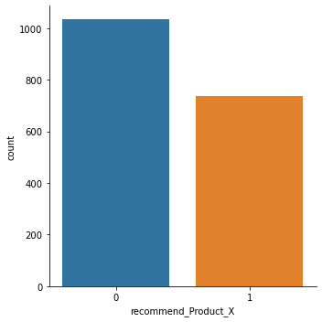

```python
# Also want to chack how balanced our dataset is in regards to our target variable "recommend_Product_X"
print(chart_review_df['recommend_Product_X'].value_counts())

sns.catplot(x='recommend_Product_X', kind="count",  data=chart_review_df)
```

# Some initial takeaways:

While theres 84 columns they can roughly be broken down into a set of 8 categories:

- General Patient info (ID, age, gender, etc.)
- rf_r?_present
- had_dx?_at_DY_dx
- currently_has_dx?
- has_ever_had_dx(22/23) (similar to currently_has)
- px_count_for_DY_tried
- currently_using_px?
- previously_tried_px?

Missing a lot of data for "rf_r6_present" and its a different data type than the other rf_r?_present categories.

Also missing a good deal of "age_at_rf_r1_dx"

We have full info regarding current/previoous dx and current px

current_severity does not have a "mild" category whereas "severity_at_DY_dx" does

Not particularly imbalanced, with about 40% vs 60% recommend X vs not. Can be addressed later in the XGBoost fitting (scale_pos_weight ~60/40) and freed in the hyperparameter fitting,

```python
# Looks like most columns are binary (0,1,or null), can check quickly
```

```python
chart_review_df.columns
```

```
Index(['patientID', 'age_at_rf_r1_dx', 'patient_gender', 'current_severity',
       'severity_at_DY_dx', 'age_current', 'DY_dx_age', 'has_had_surgery',
       'rf_r1_present', 'rf_r2_present', 'rf_r3_present', 'rf_r4_present',
       'rf_r5_present', 'rf_r6_present', 'had_dx1_at_DY_dx',
       'had_dx2_at_DY_dx', 'had_dx3_at_DY_dx', 'had_dx4_at_DY_dx',
       'had_dx5_at_DY_dx', 'had_dx6_at_DY_dx', 'had_dx7_at_DY_dx',
       'had_dx8_at_DY_dx', 'had_dx9_at_DY_dx', 'had_dx10_at_DY_dx',
       'had_dx11_at_DY_dx', 'had_dx12_at_DY_dx', 'had_dx13_at_DY_dx',
       'had_dx14_at_DY_dx', 'had_dx15_at_DY_dx', 'had_dx16_at_DY_dx',
       'had_dx17_at_DY_dx', 'had_dx18_at_DY_dx', 'had_dx19_at_DY_dx',
       'had_dx20_at_DY_dx', 'had_dx21_at_DY_dx', 'currently_has_dx1',
       'currently_has_dx2', 'currently_has_dx3', 'currently_has_dx4',
       'currently_has_dx5', 'currently_has_dx6', 'currently_has_dx7',
       'currently_has_dx8', 'currently_has_dx9', 'currently_has_dx10',
       'currently_has_dx11', 'currently_has_dx12', 'currently_has_dx13',
       'currently_has_dx14', 'currently_has_dx15', 'currently_has_dx16',
       'currently_has_dx17', 'currently_has_dx18', 'currently_has_dx19',
       'currently_has_dx20', 'currently_has_dx21', 'has_ever_had_dx22',
       'has_ever_had_dx23', 'px_count_for_DY_tried', 'currently_using_px1',
       'currently_using_px2', 'currently_using_px3', 'currently_using_px4',
       'currently_using_px5', 'currently_using_px6', 'currently_using_px7',
       'currently_using_px8', 'currently_using_px9', 'currently_using_px10',
       'currently_using_px11', 'currently_using_px12', 'previously_tried_px1',
       'previously_tried_px2', 'previously_tried_px3', 'previously_tried_px4',
       'previously_tried_px5', 'previously_tried_px6', 'previously_tried_px7',
       'previously_tried_px8', 'previously_tried_px9', 'previously_tried_px10',
       'previously_tried_px11', 'previously_tried_px12',
       'recommend_Product_X'],
      dtype='object')
```

```python
# these are the columns that appear to be binary (as well as 'px_count_for_DY_tried', which is likely not binary since its a count)
check_binary_cols = ['has_had_surgery',
       'rf_r1_present', 'rf_r2_present', 'rf_r3_present', 'rf_r4_present',
       'rf_r5_present', 'rf_r6_present', 'had_dx1_at_DY_dx',
       'had_dx2_at_DY_dx', 'had_dx3_at_DY_dx', 'had_dx4_at_DY_dx',
       'had_dx5_at_DY_dx', 'had_dx6_at_DY_dx', 'had_dx7_at_DY_dx',
       'had_dx8_at_DY_dx', 'had_dx9_at_DY_dx', 'had_dx10_at_DY_dx',
       'had_dx11_at_DY_dx', 'had_dx12_at_DY_dx', 'had_dx13_at_DY_dx',
       'had_dx14_at_DY_dx', 'had_dx15_at_DY_dx', 'had_dx16_at_DY_dx',
       'had_dx17_at_DY_dx', 'had_dx18_at_DY_dx', 'had_dx19_at_DY_dx',
       'had_dx20_at_DY_dx', 'had_dx21_at_DY_dx', 'currently_has_dx1',
       'currently_has_dx2', 'currently_has_dx3', 'currently_has_dx4',
       'currently_has_dx5', 'currently_has_dx6', 'currently_has_dx7',
       'currently_has_dx8', 'currently_has_dx9', 'currently_has_dx10',
       'currently_has_dx11', 'currently_has_dx12', 'currently_has_dx13',
       'currently_has_dx14', 'currently_has_dx15', 'currently_has_dx16',
       'currently_has_dx17', 'currently_has_dx18', 'currently_has_dx19',
       'currently_has_dx20', 'currently_has_dx21', 'has_ever_had_dx22',
       'has_ever_had_dx23', 'px_count_for_DY_tried', 'currently_using_px1',
       'currently_using_px2', 'currently_using_px3', 'currently_using_px4',
       'currently_using_px5', 'currently_using_px6', 'currently_using_px7',
       'currently_using_px8', 'currently_using_px9', 'currently_using_px10',
       'currently_using_px11', 'currently_using_px12', 'previously_tried_px1',
       'previously_tried_px2', 'previously_tried_px3', 'previously_tried_px4',
       'previously_tried_px5', 'previously_tried_px6', 'previously_tried_px7',
       'previously_tried_px8', 'previously_tried_px9', 'previously_tried_px10',
       'previously_tried_px11', 'previously_tried_px12',
       'recommend_Product_X']



for col in check_binary_cols:
    #get set of balue in columns, ignore nans
    colvals = chart_review_df[col].dropna().unique()
    if set(colvals) != set([0,1]):
        print(col, colvals)
```

```
rf_r5_present [1 3 2 4 0]
px_count_for_DY_tried [2 1 4 3 5 0]
```

px_count_for_DY_tried is as expected not binary, though interesting to note that the max value is only 5 while there are 12 px.

rf_r5_present stands out as not being binary, unlinke all the other columns we just check, and in particular the other rf columns. May indicate different levels of riskfactor e.g. low, med, high, but at the moment cant say this is the case.

```python
# If the values were almost all 0 or 1 with only a few 2,3,or 4 we could possibly infer this is a data error, but that is not the case here
chart_review_df['rf_r5_present'].value_counts()
```

```
1    857
2    577
3    183
4    129
0     27
Name: rf_r5_present, dtype: int64
```

```python
# px_count_for_DY alone does not seem a strong indicator, For most categories it roughly follows the same 40/60 split as the full sample
# exception is value of 4 which has more predicted values of 1, but this subsample is pretty small

chart_review_df.groupby(['px_count_for_DY_tried','recommend_Product_X']).count()['patientID']
```

```
px_count_for_DY_tried  recommend_Product_X
0                      0                        9
                       1                        5
1                      0                      390
                       1                      214
2                      0                      372
                       1                      279
3                      0                      204
                       1                      174
4                      0                       32
                       1                       40
5                      0                       28
                       1                       26
Name: patientID, dtype: int64
```

### Quick look at non-binary predictors

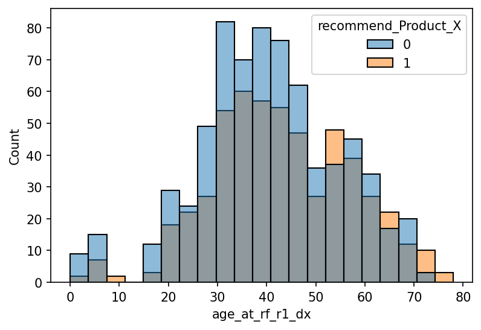

```python
plt.figure(figsize=(6, 4), dpi=150)
sns.histplot(chart_review_df,x='age_at_rf_r1_dx', hue='recommend_Product_X')
```

# Null values

'rf_r6_present' has the most missing values, with only 127 data points. However, itappears to be a very accurate indicator of 'recommend_Product_X'

```
(0.576401023357887, 1.3308157521498737e-12)
```

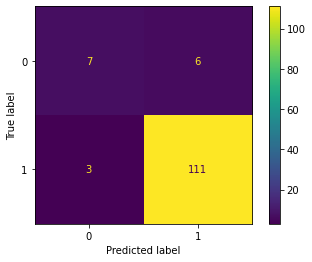

```
              precision    recall  f1-score   support

         0.0       0.70      0.54      0.61        13
         1.0       0.95      0.97      0.96       114

    accuracy                           0.93       127
   macro avg       0.82      0.76      0.78       127
weighted avg       0.92      0.93      0.92       127
```

```python
#these are pretty much only used for this quick look into the rf_r6_present and reccommend_Product_X correlation
from sklearn.metrics import confusion_matrix, ConfusionMatrixDisplay
from sklearn.metrics import classification_report

rf6 = chart_review_df[~chart_review_df['rf_r6_present'].isnull()]
print(stats.pearsonr(rf6['rf_r6_present'], rf6['recommend_Product_X']))

cm = confusion_matrix(rf6['rf_r6_present'], rf6['recommend_Product_X'])
disp = ConfusionMatrixDisplay(confusion_matrix=cm)

disp.plot()
plt.show()

print(classification_report(rf6['rf_r6_present'], rf6['recommend_Product_X']))
```

```python
rf6['recommend_Product_X'].value_counts()
```

```
1    117
0     10
Name: recommend_Product_X, dtype: int64
```

```python
# Although the sample size is very small, usingf this feature alone gives good accuracy (~93%)
accuracy = accuracy_score(rf6['rf_r6_present'], rf6['recommend_Product_X'])
print("Accuracy: {:.2f}%".format(accuracy * 100.0))
```

```
Accuracy: 92.91%
```

Maybe this is related to age somehow? Can check against the age features (Do not see any difference from the overall sample)

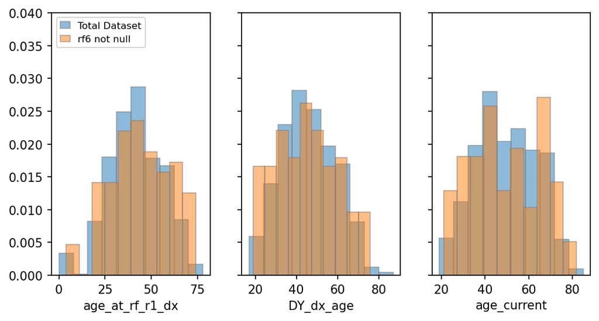

```python
fig, ax = plt.subplots(1,3, sharey=True,figsize=(8,4), dpi=150)

ax[0].hist(chart_review_df['age_at_rf_r1_dx'], density=True, edgecolor='grey',  alpha=0.5, label='Total Dataset')
ax[0].hist(rf6['age_at_rf_r1_dx'], density=True, edgecolor='grey', alpha=0.5,label= 'rf6 not null')
ax[0].legend(handlelength=1, fontsize=8, loc='upper left')
ax[0].set_ylim(0,0.04)
ax[0].set_xlabel('age_at_rf_r1_dx')

ax[1].hist(chart_review_df['DY_dx_age'], density=True, edgecolor='grey',  alpha=0.5)
ax[1].hist(rf6['DY_dx_age'], density=True, edgecolor='grey', alpha=0.5)
ax[1].set_xlabel('DY_dx_age')

ax[2].hist(chart_review_df['age_current'], density=True, edgecolor='grey',  alpha=0.5)
ax[2].hist(rf6['age_current'], density=True, edgecolor='grey', alpha=0.5)
ax[2].set_xlabel('age_current')
```

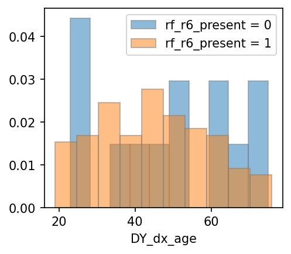

```python
# Also no apparent difference in the rf_r6_present value and age (though it is very imbalanced)

plt.figure(figsize=(3.5, 3), dpi=150)

plt.hist(rf6[rf6['rf_r6_present']==0]['DY_dx_age'], density=True, edgecolor='grey',  alpha=0.5, label='rf_r6_present = 0')
plt.hist(rf6[rf6['rf_r6_present']==1]['DY_dx_age'], density=True, edgecolor='grey', alpha=0.5, label='rf_r6_present = 1')
plt.legend()
plt.xlabel('DY_dx_age')
```

# Other null values are in the following features:

- age_at_rf_r1_dx 1242/1773 non-null
- current_severity 1766/1773 non-null
- severity_at_DY_dx 1747/1773 non-null
- previously_tried_px? 1178/1773 non-null

Overall, especially since we are using XGBoost I think for now we'll leave these as is. The null in the severity features will probably not affect the model much since there are so relatively few. May just be limited with the missing age_at_rf_r1_dx feature. previously_tried_px may be an opportunity to improve the dataset, but need to think carefully exactly how

## Feature Engineering

At this stage I dont see anything obvious to create new features. One possibility could be to simply sum the risk factor and diagnosis features. the idea being that although rf1 may not be a strong predictor, patients that have e.g. 4/5 risk factor may be more likely to be prescribed. Similar thinking with the diagnoses

```python
# Get total counts for rfs and dx
rf_cols = ['rf_r{}_present'.format(i) for i in range(1,7)]
chart_review_df['count_rf_present']= chart_review_df[rf_cols].sum(axis=1,skipna=True )

dx_cols = ['had_dx{}_at_DY_dx'.format(i) for i in range(1,22)]
chart_review_df['count_dx_at_DY_dx']= chart_review_df[dx_cols].sum(axis=1,skipna=True )


dx_cols_current = ['currently_has_dx{}'.format(i) for i in range(1,22)] + ['has_ever_had_dx22', 'has_ever_had_dx23']
chart_review_df['count_dx_current']= chart_review_df[dx_cols_current].sum(axis=1,skipna=True )

chart_review_df['time_since_DY_dx'] = chart_review_df['age_current'] - chart_review_df['DY_dx_age']
```

```python
from sklearn.cluster import AgglomerativeClustering # this is included for clustering of binary data

#NOTE: My version of scipy uses the deprecated 'affinity' argument, wihich is later renamed to 'metric'

# First cluster the first 5 risk factors
cluster_cols = ['rf_r1_present', 'rf_r2_present', 'rf_r3_present', 'rf_r4_present',
       'rf_r5_present']
chart_review_df[cluster_cols].dropna()
clustering = AgglomerativeClustering(n_clusters=2, affinity='hamming', linkage='complete').fit(np.asarray(chart_review_df[cluster_cols]))
chart_review_df['rf1_5_cluster'] = clustering.labels_


# First cluster the diagnoses at DY dx
cluster_cols = dx_cols = ['had_dx{}_at_DY_dx'.format(i) for i in range(1,22)]
chart_review_df[cluster_cols].dropna()
clustering = AgglomerativeClustering(n_clusters=2, affinity='hamming', linkage='complete').fit(np.asarray(chart_review_df[cluster_cols].dropna()))
chart_review_df['dx_at_DY_cluster'] = clustering.labels_

# Cluster the current diagnoses
cluster_cols = dx_cols_current = ['currently_has_dx{}'.format(i) for i in range(1,22)] + ['has_ever_had_dx22', 'has_ever_had_dx23']
clustering = AgglomerativeClustering(n_clusters=2, affinity='hamming', linkage='complete').fit(np.asarray(chart_review_df[cluster_cols].dropna()))
chart_review_df['dx_cluster'] = clustering.labels_
```

## Check accuracy for individual binary features

With rf6 being a very good predictor, its may be worth seeing if any other more complete columns are as well.

```
has_had_surgery Accuracy:57.98
rf_r1_present Accuracy:51.78
rf_r2_present Accuracy:55.84
rf_r3_present Accuracy:52.00
rf_r4_present Accuracy:55.56
rf_r6_present Accuracy:92.91
had_dx1_at_DY_dx Accuracy:55.56
had_dx2_at_DY_dx Accuracy:53.98
had_dx3_at_DY_dx Accuracy:48.73
had_dx4_at_DY_dx Accuracy:51.44
had_dx5_at_DY_dx Accuracy:45.52
had_dx6_at_DY_dx Accuracy:48.96
had_dx7_at_DY_dx Accuracy:47.88
had_dx8_at_DY_dx Accuracy:51.72
had_dx9_at_DY_dx Accuracy:56.80
had_dx10_at_DY_dx Accuracy:55.05
had_dx11_at_DY_dx Accuracy:56.91
had_dx12_at_DY_dx Accuracy:50.59
had_dx13_at_DY_dx Accuracy:48.90
had_dx14_at_DY_dx Accuracy:57.98
had_dx15_at_DY_dx Accuracy:51.78
had_dx16_at_DY_dx Accuracy:49.24
had_dx17_at_DY_dx Accuracy:50.03
had_dx18_at_DY_dx Accuracy:53.07
had_dx19_at_DY_dx Accuracy:50.76
had_dx20_at_DY_dx Accuracy:56.35
had_dx21_at_DY_dx Accuracy:56.06
currently_has_dx1 Accuracy:59.22
currently_has_dx2 Accuracy:57.81
currently_has_dx3 Accuracy:52.62
currently_has_dx4 Accuracy:56.46
currently_has_dx5 Accuracy:46.25
currently_has_dx6 Accuracy:51.55
currently_has_dx7 Accuracy:51.33
currently_has_dx8 Accuracy:54.99
currently_has_dx9 Accuracy:58.26
currently_has_dx10 Accuracy:56.85
currently_has_dx11 Accuracy:57.53
currently_has_dx12 Accuracy:53.41
currently_has_dx13 Accuracy:48.67
```

[output cut: 22 more lines]

```
previously_tried_px1 Accuracy:46.01
previously_tried_px2 Accuracy:51.19
previously_tried_px3 Accuracy:51.10
previously_tried_px4 Accuracy:59.34
previously_tried_px5 Accuracy:56.03
previously_tried_px6 Accuracy:52.63
previously_tried_px7 Accuracy:56.28
previously_tried_px8 Accuracy:53.90
previously_tried_px9 Accuracy:53.31
previously_tried_px10 Accuracy:54.16
previously_tried_px11 Accuracy:52.80
previously_tried_px12 Accuracy:54.16
rf1_5_cluster Accuracy:51.16
dx_cluster Accuracy:60.46
dx_at_DY_cluster Accuracy:56.63
```

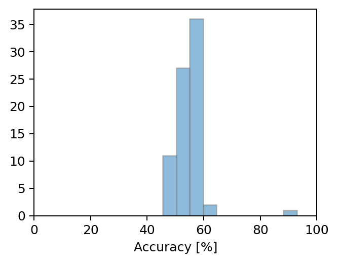

```python
new_binary_cols = check_binary_cols + ['rf1_5_cluster', 'dx_cluster', 'dx_at_DY_cluster']
remove_cols = ['px_count_for_DY_tried', 'rf_r5_present', 'recommend_Product_X']
binary_cols = [x for x in new_binary_cols if x not in remove_cols]


accuracy_vals=[]

for col in binary_cols:
    if col !='recommend_Product_X':
        col_df = chart_review_df[~chart_review_df[col].isnull()]
        accuracy = accuracy_score(col_df[col], col_df['recommend_Product_X'])
        print("{} Accuracy:{:.2f}".format(col, accuracy * 100.0))

        accuracy_vals.append(accuracy*100)

plt.figure(figsize=(4,3), dpi=180)
plt.hist(accuracy_vals, edgecolor='grey', alpha=0.5)
plt.xlim(0,100)
plt.xlabel('Accuracy [%]')
```

## Check Correlation Matrix

Here Ill take a quick look at the correlation between parameters. I will focus on the binary features (since thats the majority of our features). Therefore Ill use the phik_matrix() (https://phik.readthedocs.io/en/latest/) which is built to better handle binary data correlations vs a typical pandas.corr()

```
interval columns not set, guessing: ['has_had_surgery', 'rf_r1_present', 'rf_r2_present', 'rf_r3_present', 'rf_r4_present', 'rf_r6_present', 'had_dx1_at_DY_dx', 'had_dx2_at_DY_dx', 'had_dx3_at_DY_dx', 'had_dx4_at_DY_dx', 'had_dx5_at_DY_dx', 'had_dx6_at_DY_dx', 'had_dx7_at_DY_dx', 'had_dx8_at_DY_dx',…
```

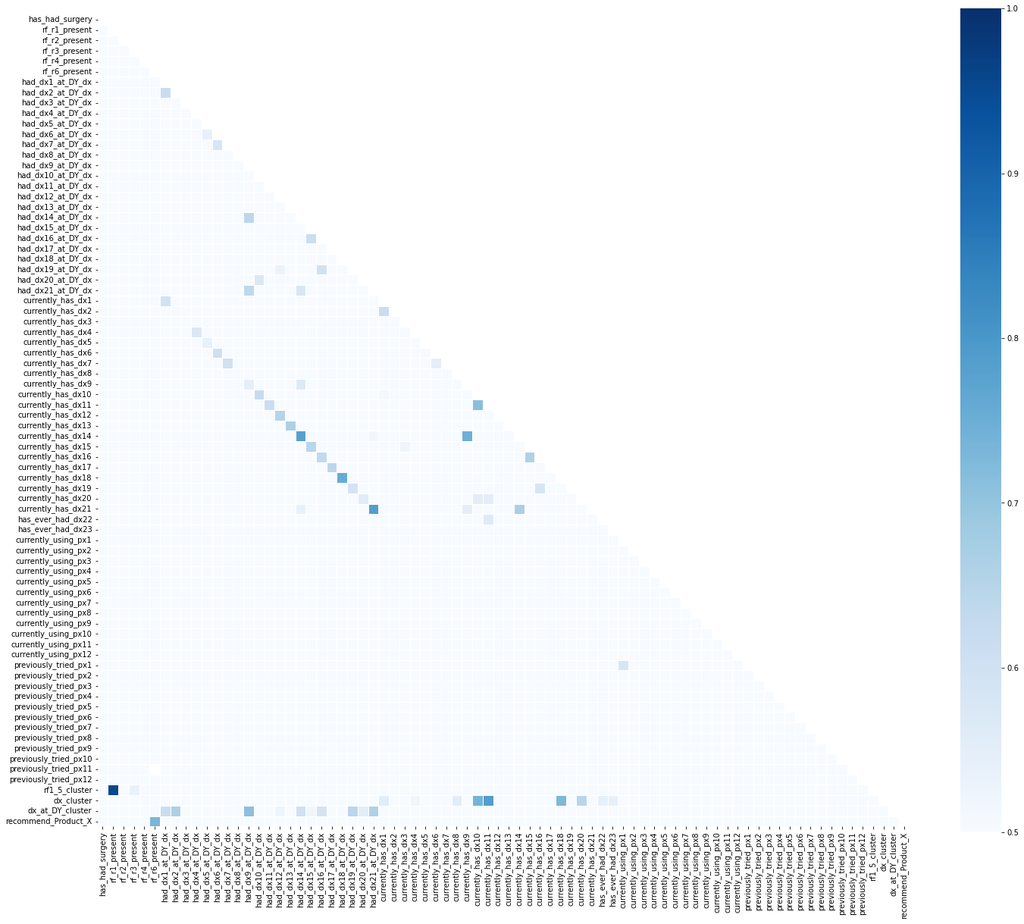

```python
## Check correlations

corr = chart_review_df[binary_cols + ['recommend_Product_X']].phik_matrix()

# Generate a mask for the upper triangle
mask = np.triu(np.ones_like(corr, dtype=bool))


fig, ax = plt.subplots(figsize=(24, 20))



# Draw the heatmap with the mask and correct aspect ratio
# vmin = 0.5 to highlight most highly correlated values

sns.heatmap(corr, mask=mask, cmap='Blues', vmin=0.5, vmax=1,
            square=True, linewidths=.5, )
```

```python
chart_review_df[['rf_r6_present','recommend_Product_X']].significance_matrix()
```

```
interval columns not set, guessing: ['rf_r6_present', 'recommend_Product_X']
```

|  | rf_r6_present | recommend_Product_X |
| --- | --- | --- |
| rf_r6_present | 8.717719 | 4.837962 |
| recommend_Product_X | 4.837962 | 48.717063 |

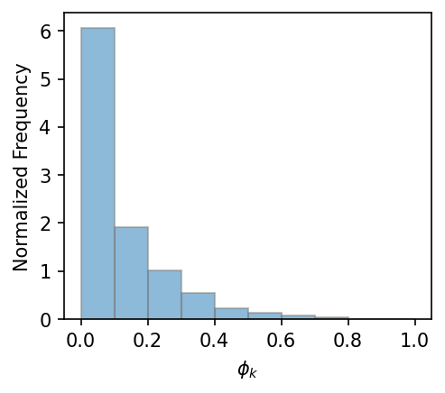

```python
# To get a better sense of the correlations between parameters, plot the histogramn (this includes duplicates (i.e. the upper triangle of the correlation matrix)
fig= plt.figure(figsize=(3.5, 3), dpi=150)
density=True
corr_vals = (np.array(corr[(corr!=1)]).flatten())
#plt.semilogy()
plt.hist(corr_vals, edgecolor='grey',density=density, alpha=0.5, bins=np.linspace(0,1,11))
plt.xlabel('$\phi_k$')
if density:
    plt.ylabel('Normalized Frequency')
else:
    plt.ylabel('Count')
```

No major insights here. Some unsurprising correlations, such as

- the currently_hs_dx' and 'had dx_ata_DY_dx'.
- The cluster features are mostly correlatied with the features they were clustered on
- rf_r6_present and recommend_Product_X, which is discussed in more detail above.

Not shown here but checking the correlations using standard correlation (e.g. pandas df.corr()) and including the non-binary features, another unsurprising correlation is between the various age features

### Label Encoding

Here we'll add encoding for the categorical variables: 'patient_gender', 'severity_at_DY_dx', 'current_severity'

```python
## Label Encoder
# Classes for current severity are
from sklearn.preprocessing import LabelEncoder
le = LabelEncoder()
```

#### Patient gender

```python
# double check that 'M' and 'F' are the only options, then convert to binary
chart_review_df['patient_gender'].unique()
```

```
array(['F', 'M'], dtype=object)
```

```python
chart_review_df['patient_gender_enc'] = (chart_review_df['patient_gender'] == 'M').astype(int)
chart_review_df['patient_gender_enc'].unique()
```

```
array([0, 1])
```

```python
print(chart_review_df['current_severity'].value_counts()  )
print(np.sum(chart_review_df['current_severity'].isnull()))
```

```
Moderate    1582
Severe       184
Name: current_severity, dtype: int64
7
```

```python
le.fit(chart_review_df['severity_at_DY_dx'])
chart_review_df['severity_at_DY_dx_enc'] = le.transform(chart_review_df['severity_at_DY_dx'])
le.fit(chart_review_df['current_severity'])
chart_review_df['current_severity_enc'] = le.transform(chart_review_df['current_severity'])
```

# Baseline model using XGBoost

```python
# These columns will be dropped from the training data
# PatientID is uninformative, recommend_Product_X is the Target, and the others have been encoded
drop_cols = ['patientID','current_severity','severity_at_DY_dx','patient_gender','recommend_Product_X']
```

```python
fit_df = chart_review_df


X, y = fit_df.drop(columns=drop_cols), fit_df['recommend_Product_X']
X_train, X_test, y_train, y_test = train_test_split(X, y, test_size=0.3, random_state=42)
evalset = [(X_train, y_train), (X_test,y_test)]
```

```python
try:
    del DisYBoost
except:
    print("DisYBoost does not exist, will instantiate")

# Here we will define our first baseline version of the model, using mainly default parameters, but increse n_estimators to get more learning curve coverage
n_estimators = 150
seed = 0

DisYBoost = XGBClassifier(n_estimators=n_estimators, seed=seed, eval_metric='logloss')

DisYBoost.fit(X_train, y_train,  eval_set=evalset,verbose=False)


# make predictions for test data
y_pred = DisYBoost.predict(X_test)

# evaluate predictions
accuracy = accuracy_score(y_test, y_pred)
print("Train-Test-Split Accuracy: %.2f%%" % (accuracy * 100.0))
```

```
DisYBoost does not exist, will instantiate
Train-Test-Split Accuracy: 82.89%
```

```python
#Also check K-fold cross validation

kfold = KFold(n_splits=10, shuffle=True,random_state=0)
results = cross_val_score(DisYBoost, X, y, cv=kfold)
print("K-fold Accuracy: {:.2f}% ({:.2f}%)".format(results.mean()*100, results.std()*100))
```

```
K-fold Accuracy: 85.84% (2.54%)
```

### Check Learning Curves

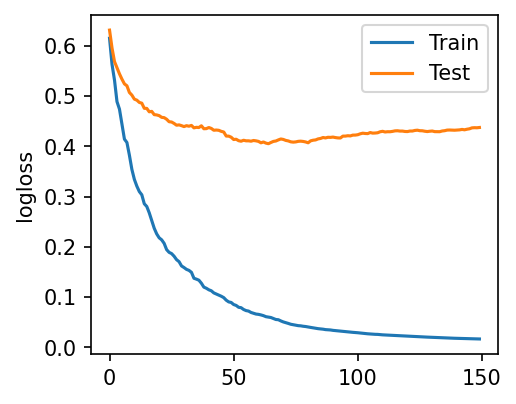

```python
#Here we can check learning cruves for our model using logloss
results_pre_opt = DisYBoost.evals_result()
plt.figure(figsize=(3.5, 3), dpi=150)
# plot learning curves
plt.plot(results_pre_opt['validation_0']['logloss'], label='Train')
plt.plot(results_pre_opt['validation_1']['logloss'], label='Test')
plt.ylabel('logloss')
plt.legend()
```

Overall the test and train set are fairly disparate, we can hopefully do better. Looks like learning stops on the test set ~75, levels out for training at right around 150

## Feature importances from the model

To start we can look at the feature importance from xgboosts plot*importance function. At the top of the list we have age categories and the count categories that stand out relative to the others. Interestingly the "count*" features added seem to have higher importance, though doesnt seem to effect the model much (compared to previous versions without it)

However, these importances are showing the F-score from XGBoost, which may be biased to the features containing larger numerical values (i.e. ages and count features)

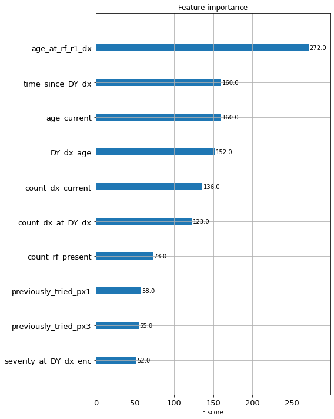

```python
fig, ax = plt.subplots(1,1,figsize=(8,10))
# plot feature importance
plot_importance(DisYBoost, max_num_features=10,ax=ax, ylabel=None)
ax.tick_params(axis='both', which='major', labelsize=13)
ax.tick_params(axis='both', which='minor', labelsize=13)

plt.tight_layout()
#plt.savefig('feat_import_F.png', facecolor='white', transparent=False)
```

A perhaps more informative measure of the feature importance is the gain (which is the default used in XGBoost). We have to manually extract and plot these values.

Once we do, we see that the rf_r6_present has easily the highest gain value, as is reasonable based on the discussion in the EDA section (i.e. ~93% accuracy from this alone)

Following this there are other features that seem to be reasonable predictors (e.g. current_severity, a couple other risk factors etc.)

After our hyperparameter optimization we can test how removing the lowest features affects the model performance

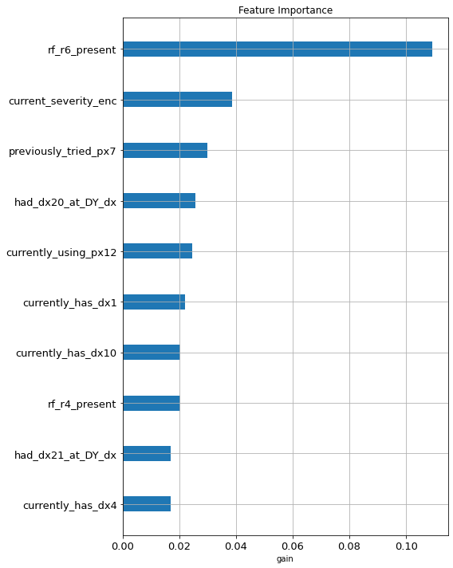

```python
# Get default feature_importance values (i.e. gain) and create a sorted dictionary
feature_names  = X_train.columns.tolist()
feat_imp_dict = dict(zip(feature_names, DisYBoost.feature_importances_))
feat_imp_dict = {k: v for k, v in sorted(feat_imp_dict.items(), key=lambda item: item[1], reverse=True)}


#plot the feature importances
fig, ax = plt.subplots(1,1,figsize=(8,10))




#limt to top 15
limit = 10
ax.grid(zorder=0)
ax.barh(list(feat_imp_dict.keys())[:limit], list(feat_imp_dict.values())[:limit], height=0.3)
ax.invert_yaxis()
ax.set_xlabel('gain')
#ax.set_ylabel('Features')
ax.tick_params(axis='both', which='major', labelsize=13)
ax.tick_params(axis='both', which='minor', labelsize=13)


plt.title('Feature Importance')
plt.tight_layout()
#plt.savefig('feat_import_gain.png', facecolor='white', transparent=False)
```

# Hyperparameter Tuning

```python
from hyperopt import hp, fmin, tpe, STATUS_OK, Trials

hyp_params = {
    'max_depth': hp.choice('max_depth', np.arange(5, 15, dtype=int)),
    'learning_rate': hp.loguniform('learning_rate', -5, -2),
    'subsample': hp.uniform('subsample', 0.25, 1),
    #'gamma': hp.uniform ('gamma', 0,2),
    'colsample_bytree' : hp.uniform('colsample_bytree', 0.5,1),
    'min_child_weight' : hp.quniform('min_child_weight', 0, 10, 1),
    'scale_pos_weight' : hp.uniform('scale_pos_weight', 1,2),
}
```

```python
# An objective function is needed for the hyperopt tuning
def objective(hyp_params):
    clf=XGBClassifier(n_estimators=n_estimators,seed=seed,eval_metric='logloss', **hyp_params)

    evaluation = [( X_train, y_train), ( X_test, y_test)]

    clf.fit(X_train, y_train,
            eval_set=evaluation,  verbose=False)


    pred = clf.predict(X_test)
    accuracy_clf = accuracy_score(y_test, pred)
    print ("SCORE: {:.3f}".format( accuracy_clf))
    return {'loss': -accuracy_clf, 'status': STATUS_OK }
```

```python
trials = Trials()
best_params = fmin(objective, hyp_params, algo=tpe.suggest, max_evals=100, trials=trials)
print("Best set of hyperparameters: ", best_params)
```

```
SCORE: 0.793
SCORE: 0.763
SCORE: 0.827
SCORE: 0.778
SCORE: 0.769
SCORE: 0.776
SCORE: 0.773
SCORE: 0.786
SCORE: 0.754
SCORE: 0.793
SCORE: 0.722
SCORE: 0.821
SCORE: 0.733
SCORE: 0.823
SCORE: 0.746
SCORE: 0.758
SCORE: 0.803
SCORE: 0.793
SCORE: 0.806
SCORE: 0.769
SCORE: 0.855
SCORE: 0.850
SCORE: 0.842
SCORE: 0.850
SCORE: 0.842
SCORE: 0.825
SCORE: 0.835
SCORE: 0.863
SCORE: 0.820
SCORE: 0.816
SCORE: 0.808
SCORE: 0.846
SCORE: 0.803
SCORE: 0.827
SCORE: 0.844
SCORE: 0.786
SCORE: 0.810
SCORE: 0.812
SCORE: 0.850
SCORE: 0.831
```

[output cut: 46 more lines]

```
SCORE: 0.799
SCORE: 0.789
SCORE: 0.835
SCORE: 0.789
SCORE: 0.840
SCORE: 0.835
SCORE: 0.821
SCORE: 0.810
SCORE: 0.842
SCORE: 0.855
SCORE: 0.780
SCORE: 0.831
SCORE: 0.793
SCORE: 0.836
Best set of hyperparameters:  {'colsample_bytree': 0.7821259274531891, 'learning_rate': 0.1257993515650235, 'max_depth': 7, 'min_child_weight': 1.0, 'scale_pos_weight': 1.5687552539436538, 'subsample': 0.9214027984930189}
```

```python
#DisYBoost_HT is the Hypertuned model

DisYBoost_HT = XGBClassifier(n_estimators=n_estimators,seed=seed, eval_metric='logloss',  **best_params)


eval_set = [( X_train, y_train), ( X_test, y_test)]

DisYBoost_HT.fit(X_train, y_train, eval_set=eval_set, verbose=False)


# make predictions for test data
y_pred = DisYBoost_HT.predict(X_test)

# evaluate predictions
accuracy_HT = accuracy_score(y_test, y_pred)
print("Train-test-split Accuracy: {:.2f}%".format(accuracy_HT * 100.0))
```

```
Train-test-split Accuracy: 83.46%
```

```python
kfold = KFold(n_splits=10, shuffle=True,random_state=0)
results_HT = cross_val_score(DisYBoost_HT, X,y, cv=kfold)
print("Accuracy: {:.2f}% ({:.2f}%)".format(results_HT.mean()*100, results_HT.std()*100))

# Basically the same as previous prior to tuning. Slightly slower std
# Accuracy: 85.79% (2.27%)
```

```
Accuracy: 86.29% (2.11%)
```

```python
# Drop lower importance features
accuracy_scores = []
thresholds = np.sort(DisYBoost_HT.feature_importances_)
for thresh in list(thresholds):

    # select features using threshold
    selection = SelectFromModel(DisYBoost_HT, threshold=thresh, prefit=True)
    select_X_train = selection.transform(X_train)

    # train model
    selection_model = XGBClassifier(n_estimators=n_estimators,seed=seed, eval_metric='logloss',**best_params)
    selection_model.fit(select_X_train, y_train)

    # eval model
    select_X_test = selection.transform(X_test)
    predictions = selection_model.predict(select_X_test)
    accuracy_thresh = accuracy_score(y_test, predictions)

    accuracy_scores.append([thresh,accuracy_thresh*100])
    print("Thresh={:.3f}, num_features={}, Accuracy: {:.2f}%".format(thresh, select_X_train.shape[1], accuracy_thresh*100.0))
```

```
Thresh=0.004, num_features=89, Accuracy: 83.46%
```

```
Thresh=0.004, num_features=88, Accuracy: 84.96%
```

```
Thresh=0.005, num_features=87, Accuracy: 84.96%
```

```
Thresh=0.006, num_features=86, Accuracy: 82.52%
```

```
Thresh=0.006, num_features=85, Accuracy: 84.02%
```

```
Thresh=0.006, num_features=84, Accuracy: 84.02%
```

```
Thresh=0.006, num_features=83, Accuracy: 84.77%
```

```
Thresh=0.006, num_features=82, Accuracy: 84.96%
```

```
Thresh=0.007, num_features=81, Accuracy: 84.59%
```

```
Thresh=0.007, num_features=80, Accuracy: 83.08%
```

```
Thresh=0.007, num_features=79, Accuracy: 85.34%
```

```
Thresh=0.007, num_features=78, Accuracy: 83.27%
```

```
Thresh=0.007, num_features=77, Accuracy: 84.21%
```

```
Thresh=0.008, num_features=76, Accuracy: 83.83%
```

```
Thresh=0.008, num_features=75, Accuracy: 83.65%
```

```
Thresh=0.008, num_features=74, Accuracy: 83.08%
```

```
Thresh=0.008, num_features=73, Accuracy: 83.27%
```

```
Thresh=0.008, num_features=72, Accuracy: 82.89%
```

```
Thresh=0.008, num_features=71, Accuracy: 82.71%
```

```
Thresh=0.008, num_features=70, Accuracy: 83.83%
```

```
Thresh=0.008, num_features=69, Accuracy: 83.46%
```

```
Thresh=0.008, num_features=68, Accuracy: 83.08%
```

```
Thresh=0.009, num_features=67, Accuracy: 83.65%
```

```
Thresh=0.009, num_features=66, Accuracy: 84.02%
```

```
Thresh=0.009, num_features=65, Accuracy: 84.21%
```

```
Thresh=0.009, num_features=64, Accuracy: 83.27%
```

```
Thresh=0.009, num_features=63, Accuracy: 81.77%
```

```
Thresh=0.009, num_features=62, Accuracy: 83.27%
```

```
Thresh=0.009, num_features=61, Accuracy: 83.83%
```

```
Thresh=0.009, num_features=60, Accuracy: 83.46%
```

```
Thresh=0.009, num_features=59, Accuracy: 83.08%
```

```
Thresh=0.009, num_features=58, Accuracy: 83.83%
```

```
Thresh=0.009, num_features=57, Accuracy: 83.46%
```

```
Thresh=0.010, num_features=56, Accuracy: 82.14%
```

```
Thresh=0.010, num_features=55, Accuracy: 82.33%
```

```
Thresh=0.010, num_features=54, Accuracy: 82.89%
```

```
Thresh=0.010, num_features=53, Accuracy: 83.46%
```

```
Thresh=0.010, num_features=52, Accuracy: 83.83%
```

```
Thresh=0.010, num_features=51, Accuracy: 84.21%
```

```
Thresh=0.010, num_features=50, Accuracy: 83.27%
```

```
Thresh=0.010, num_features=49, Accuracy: 81.39%
```

```
Thresh=0.010, num_features=48, Accuracy: 81.95%
```

```
Thresh=0.010, num_features=47, Accuracy: 83.08%
```

```
Thresh=0.010, num_features=46, Accuracy: 83.27%
```

```
Thresh=0.010, num_features=45, Accuracy: 84.59%
```

```
Thresh=0.010, num_features=44, Accuracy: 83.83%
```

```
Thresh=0.010, num_features=43, Accuracy: 82.71%
```

```
Thresh=0.010, num_features=42, Accuracy: 83.27%
```

```
Thresh=0.010, num_features=41, Accuracy: 82.33%
```

```
Thresh=0.010, num_features=40, Accuracy: 83.27%
```

```
Thresh=0.010, num_features=39, Accuracy: 83.08%
```

```
Thresh=0.010, num_features=38, Accuracy: 83.65%
```

```
Thresh=0.011, num_features=37, Accuracy: 82.71%
```

```
Thresh=0.011, num_features=36, Accuracy: 82.33%
```

```
Thresh=0.011, num_features=35, Accuracy: 82.33%
```

```
Thresh=0.011, num_features=34, Accuracy: 79.70%
```

```
Thresh=0.011, num_features=33, Accuracy: 80.08%
```

```
Thresh=0.011, num_features=32, Accuracy: 79.89%
```

```
Thresh=0.011, num_features=31, Accuracy: 81.20%
```

```
Thresh=0.011, num_features=30, Accuracy: 81.20%
```

```
Thresh=0.011, num_features=29, Accuracy: 81.02%
```

```
Thresh=0.011, num_features=28, Accuracy: 79.32%
```

```
Thresh=0.011, num_features=27, Accuracy: 80.08%
```

```
Thresh=0.011, num_features=26, Accuracy: 78.95%
```

```
Thresh=0.011, num_features=25, Accuracy: 77.26%
```

```
Thresh=0.011, num_features=24, Accuracy: 74.62%
```

```
Thresh=0.011, num_features=23, Accuracy: 75.38%
```

```
Thresh=0.012, num_features=22, Accuracy: 74.06%
```

```
Thresh=0.012, num_features=21, Accuracy: 74.62%
```

```
Thresh=0.012, num_features=20, Accuracy: 73.50%
```

```
Thresh=0.012, num_features=19, Accuracy: 73.12%
```

```
Thresh=0.012, num_features=18, Accuracy: 73.31%
```

```
Thresh=0.012, num_features=17, Accuracy: 71.24%
```

```
Thresh=0.013, num_features=16, Accuracy: 70.30%
```

```
Thresh=0.013, num_features=15, Accuracy: 67.86%
```

```
Thresh=0.013, num_features=14, Accuracy: 67.86%
```

```
Thresh=0.014, num_features=13, Accuracy: 69.74%
```

```
Thresh=0.014, num_features=12, Accuracy: 65.23%
```

```
Thresh=0.015, num_features=11, Accuracy: 65.79%
Thresh=0.015, num_features=10, Accuracy: 64.29%
```

```
Thresh=0.015, num_features=9, Accuracy: 65.04%
Thresh=0.015, num_features=8, Accuracy: 66.35%
```

```
Thresh=0.016, num_features=7, Accuracy: 63.35%
Thresh=0.017, num_features=6, Accuracy: 66.17%
```

```
Thresh=0.017, num_features=5, Accuracy: 64.85%
Thresh=0.018, num_features=4, Accuracy: 69.17%
Thresh=0.019, num_features=3, Accuracy: 68.80%
```

```
Thresh=0.040, num_features=2, Accuracy: 68.80%
Thresh=0.078, num_features=1, Accuracy: 64.47%
```

```python
accuracy_scores=np.asarray(accuracy_scores)
```

```
Max accuracy: 85.34% at thresh 0.007127
```

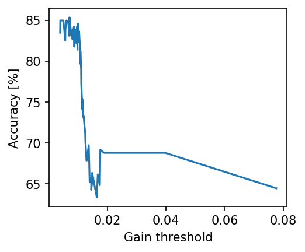

```python
max_accuracy = max(accuracy_scores[:,1])
max_threshold = accuracy_scores[np.argmax(accuracy_scores[:,1]),0]

print("Max accuracy: {:.2f}% at thresh {:3f}".format(max_accuracy, max_threshold))

plt.figure(figsize=(3.5,3), dpi=150)
plt.plot(accuracy_scores[:,0], accuracy_scores[:,1])
plt.xlabel('Gain threshold')
plt.ylabel('Accuracy [%]')
#not sure why this got worse, but I think its good motivation to not include any feature importance based cuts
# Max accuracy: 84.40% at thresh 0.007778
```

No justifiction for removing features based on importance

```python
# define the datasets to evaluate each iteration
evalset = [(X_train, y_train), (X_test,y_test)]

DisYBoost_HT.fit(X_train, y_train, eval_set=evalset)
results_post_opt = DisYBoost_HT.evals_result()
```

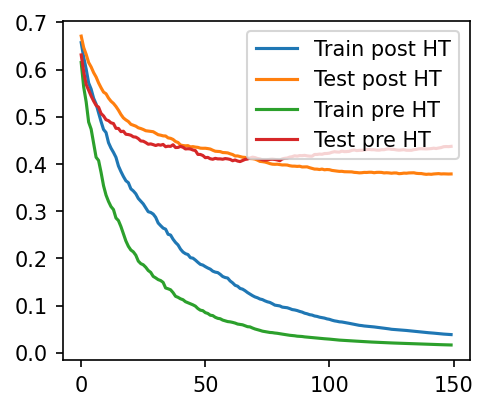

```python
plt.figure(figsize=(3.5, 3), dpi=150)
# plot learning curves
plt.plot(results_post_opt['validation_0']['logloss'], label='Train post HT')
plt.plot(results_post_opt['validation_1']['logloss'], label='Test post HT')

plt.plot(results_pre_opt['validation_0']['logloss'], label='Train pre HT')
plt.plot(results_pre_opt['validation_1']['logloss'], label='Test pre HT' )

plt.legend()
plt.show()
```